# Penguin Regression with Caret

SHIN, Eon Seok

2021 8 20

## **회귀 예상문제 및 풀이**

이 문제는 개인적으로 공부하기 위하여 작성한 예상문제로 회귀분석 머신러닝 과정 전체를  
리뷰한 내용입니다  
비교적 단순한 데이터인 팔머 펭귄데이터로 펭귄의 중량을 예측하는 문제입니다.

```r
library(tidyverse)
library(palmerpenguins)
library(caret)
library(knitr)
library(mice)
library(corrplot)
```

### **문제 I**

PalmerPenguin 데이터를 가지고 다음을 수행하시오.  
1. 데이터 준비  
a) 결측치 여부 확인 및 결측치 처리  
b) 펭귄의 무게를 예측하는데 불필요한 변수(island, year)를 제거하고  
factor형 변수인 species와 sex를 더미화 시키시오.  
c) 데이터를 학습용 80% 검증용 20%로 분할하시오.  
d) 학습용 데이터는 10-Fold Cross Validation으로 학습을 진행하시오.  
2. 펭귄의 무게(body_mass_g)를 예측하는 회귀를 다음 모형을 포함하여 수행하시오.  
a) 선형 모델인 선형회귀(lm)와 페널티 선형회귀(glmnet) 모형  
b) 비선형 모델인 회귀나무(CART), 서포트벡터머신(SVM) k-근접이웃(KNN) 모형  
c) 앙상블 모형인 랜덤포레스트(RF), 그라디언트부스팅(GBM), CUBIST 모형  
이상의 8종의 모형으로 회귀를 수행하고 평가지표 중 하나인 RMSE를 기준으로  
모형별 성능을 비교 분석하시오  
3) 위 2번에서 생성된 모형의 예측 성능을 개선시키기 위하여, 다음을 수행하시오.  
a) 데이터를 scaling, centrering하여 표준화 시킨후 위 2번 모형으로 회귀분석을 실시하고, 평가지표의 변화가 얼마나 있는지 분석하여 제시하시오.  
b) a)번의 수행결과 선형모델, 비선형모델, 앙상블 모형별로 가장 성능이 우수한 모형을 하나씩 선정하여 각각 적절한 파라메터 튜닝을 수행한후, 파라메터 튜닝결과로 발생한 성능 개선 효과를 제시하시오.  
c) 종합적으로 성능지표(RMSE)가 가장 우수한 모형을 Final 모형으로 선정하시오.  
4) 3번에서 선정된 Final 모형으로 검증용 데이터의 펭귄체중을 예측하여  
RMSE를 제시하시오.

```r
library(tidyverse)
library(palmerpenguins)
library(caret)
library(knitr)
library(mice)   # Multivariate Imputation by Chained Equations

#--->>> 기본 데이터 전처리
p <- penguins
summary(p)           # na값 확인
```

```
      species          island    bill_length_mm  bill_depth_mm
 Adelie   :152   Biscoe   :168   Min.   :32.10   Min.   :13.10
 Chinstrap: 68   Dream    :124   1st Qu.:39.23   1st Qu.:15.60
 Gentoo   :124   Torgersen: 52   Median :44.45   Median :17.30
                                 Mean   :43.92   Mean   :17.15
                                 3rd Qu.:48.50   3rd Qu.:18.70
                                 Max.   :59.60   Max.   :21.50
                                 NA's   :2       NA's   :2
 flipper_length_mm  body_mass_g       sex           year
 Min.   :172.0     Min.   :2700   female:165   Min.   :2007
 1st Qu.:190.0     1st Qu.:3550   male  :168   1st Qu.:2007
 Median :197.0     Median :4050   NA's  : 11   Median :2008
 Mean   :200.9     Mean   :4202                Mean   :2008
 3rd Qu.:213.0     3rd Qu.:4750                3rd Qu.:2009
 Max.   :231.0     Max.   :6300                Max.   :2009
 NA's   :2         NA's   :2
```

```r
# Imputation Using mice
p_mice <- mice(p, printFlag = FALSE, seed = 6439)
p_new <- complete(p_mice)  #  p_new 는 NO NA 데이터
summary(p_new)
```

```
      species          island    bill_length_mm  bill_depth_mm
 Adelie   :152   Biscoe   :168   Min.   :32.10   Min.   :13.10
 Chinstrap: 68   Dream    :124   1st Qu.:39.20   1st Qu.:15.60
 Gentoo   :124   Torgersen: 52   Median :44.45   Median :17.30
                                 Mean   :43.91   Mean   :17.15
                                 3rd Qu.:48.50   3rd Qu.:18.70
                                 Max.   :59.60   Max.   :21.50
 flipper_length_mm  body_mass_g       sex           year
 Min.   :172.0     Min.   :2700   female:174   Min.   :2007
 1st Qu.:190.0     1st Qu.:3550   male  :170   1st Qu.:2007
 Median :197.0     Median :4050                Median :2008
 Mean   :201.0     Mean   :4203                Mean   :2008
 3rd Qu.:213.2     3rd Qu.:4756                3rd Qu.:2009
 Max.   :231.0     Max.   :6300                Max.   :2009
```

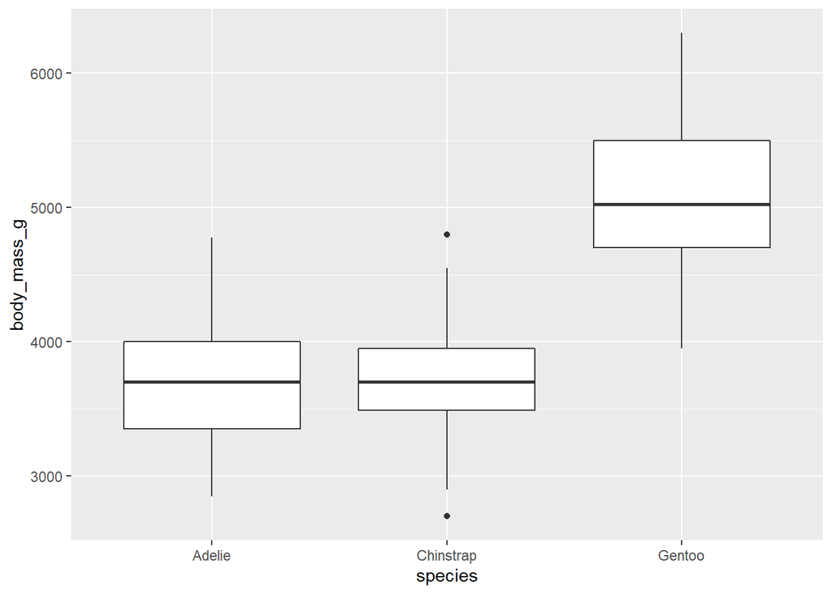

```r
#--->>> 데이터 가시화 추가
p_new$year <- factor(p_new$year)

# 몇가지 가시화
# 종별 무게차이가 있을까?
ggplot(p_new,
       aes(x = species, y = body_mass_g))  +
  geom_boxplot()
```

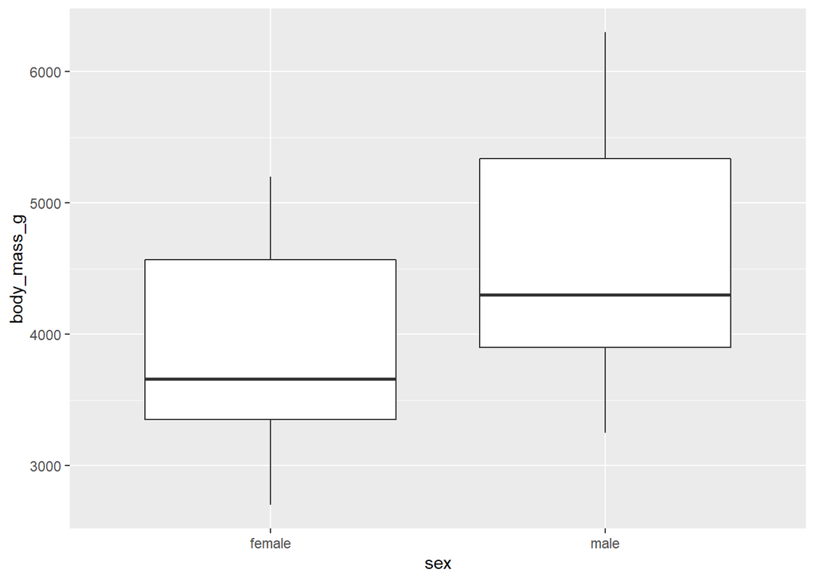

```r
# 성별로 무게 차이가 있을까?
ggplot(p_new,
       aes(x =sex, y = body_mass_g))  +
  geom_boxplot()
```

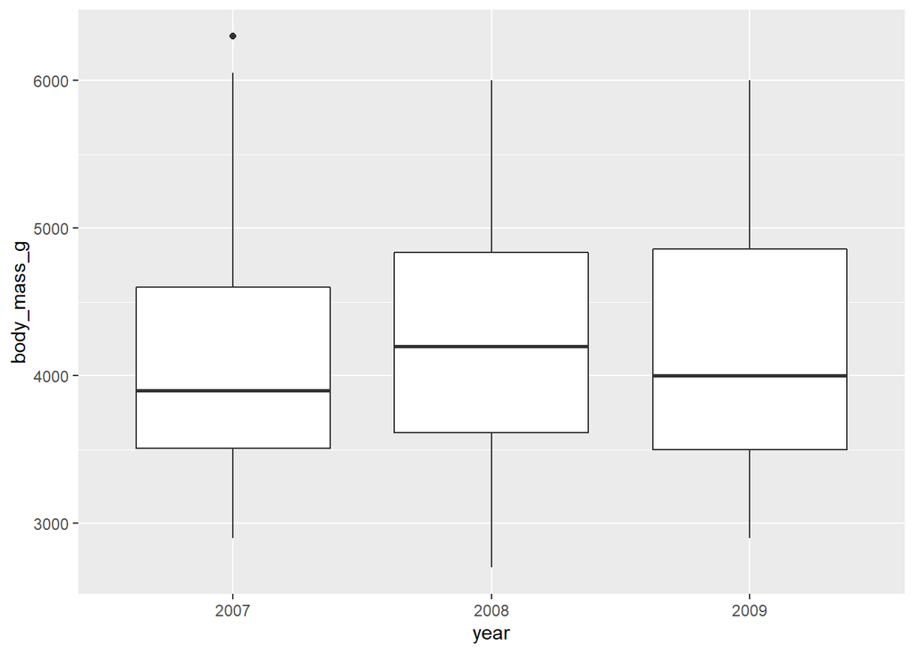

```r
# 조사연도별
ggplot(p_new,
       aes(x =year, y = body_mass_g))  +
  geom_boxplot()   # 차이가 거의없어 보이는데
```

```r
# 분산분석을 해서 연도별로 차이가 있는지 알아보자
summary(aov(body_mass_g ~ year, data = p_new))
```

```
             Df    Sum Sq Mean Sq F value Pr(>F)
year          2   1290014  645007   0.998   0.37
Residuals   341 220399550  646333
```

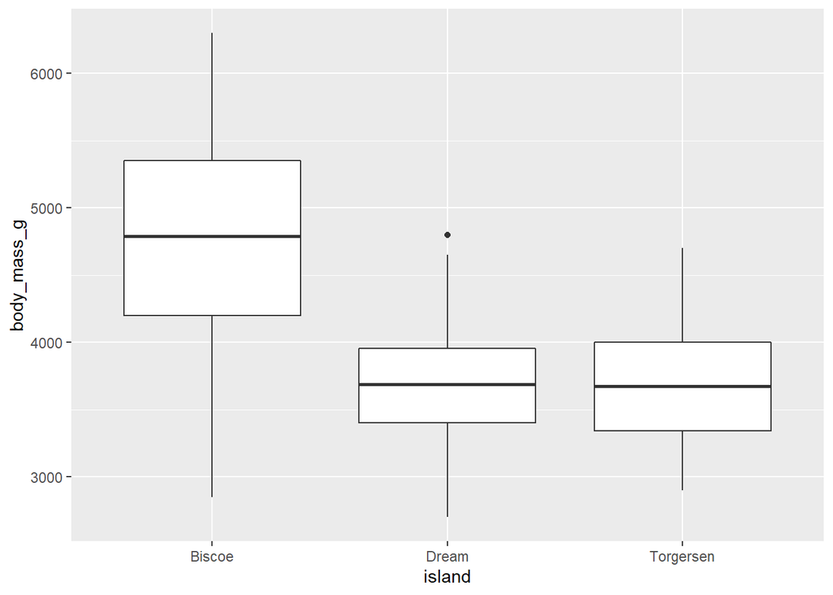

```r
# p-value가 0.4로 귀무가설 기각 못함. 즉 평균의 차이가 없다.
# 따라서 펭귄의 체충을 예측하는데
# <<<조사년도는 불필요 판단 >>>

# 서식하는 지역(섬) 별로 무게 차이가 있을까?
ggplot(p_new,
       aes(x =island, y = body_mass_g))  +
  geom_boxplot()      # 서식지역별로  차이가 있어보이는데...
```

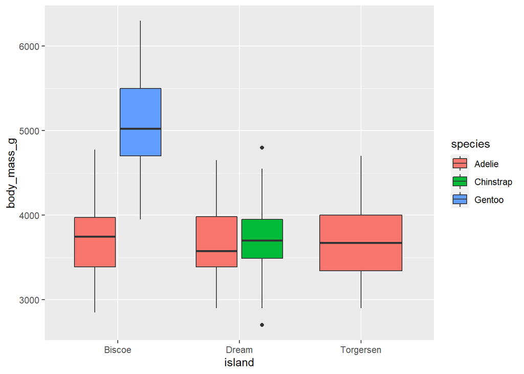

```r
ggplot(p_new,
       aes(x =island, y = body_mass_g, fill=species))  +
  geom_boxplot()  # 서직지역별로 펭귄의 품종이 달라서 나타난 현상
```

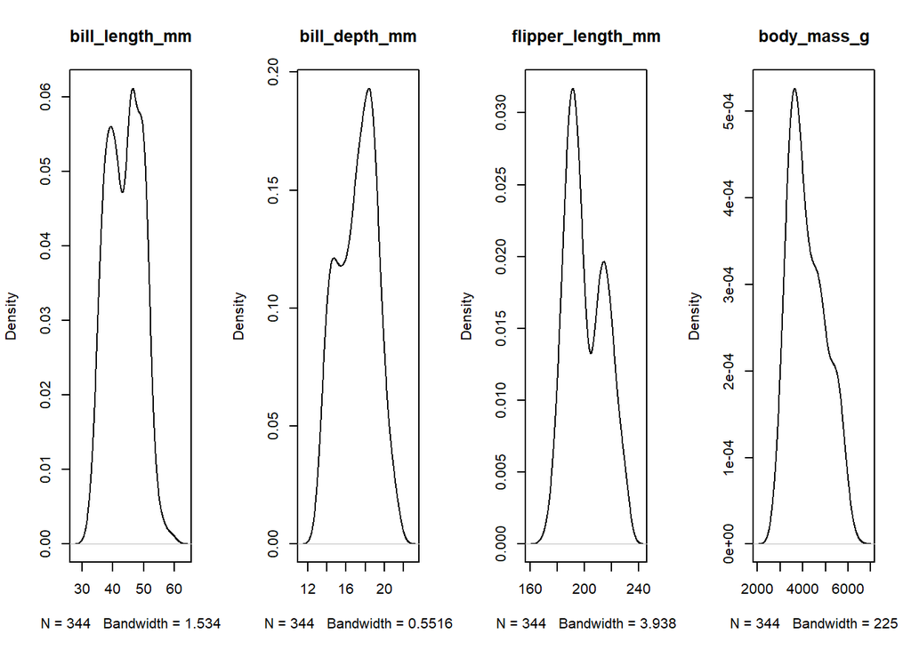

```r
                  # 다른섬에 사는 아델리 평균의 경우 체중 차이 없음
#  <<< 서식지역은 체중 판단에 불필요 >>>

# 연속형 변수들의 분포를 살펴보자.
par(mfrow = c(1,4))
for(i in 3:6) {plot(density(p_new[,i]), main = names(p_new[i]))}
```

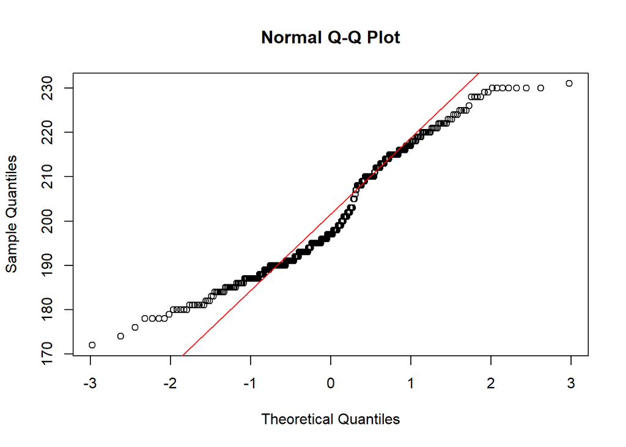

```r
#  예들들어 flipper_length_mm 같은 경우 정규분포를 따른다고 하기 어렵네.
#  정규성을 확인해보자.
par(mfrow = c(1,1))
qqnorm(p_new$flipper_length_mm)
qqline(p_new$flipper_length_mm, col = "red")
```

```r
shapiro.test(p_new$flipper_length_mm)
```

```
    Shapiro-Wilk normality test

data:  p_new$flipper_length_mm
W = 0.95198, p-value = 3.699e-09
```

```r
# 샤피로 검정결과 정규성 따른다는 귀무가설 기각

# 소결론 : 연속형변수들이 정규분포를 따른다느 가정하에
#          회귀분석을 하기 어려움 ---> 변환 필요 (Box-Cox변환)

# 데이터를 만져보니....
# 회귀모델에 적용시키기 전에 몇가지 처리 필요함을 확인했음.
#  1. Feature Selection : 불필요변수(island, year) 제거
#  2. 연속형변수의 Box-Cox 변환 필요  ----> data preprocessing에 포함

p_new  <- p_new[ ,c(-2, -8)]   # 불필요 변수 제거
#--->>> 데이터 터미화 : species와 sex 더미화
dummys <- dummyVars(~ species+sex, data= p_new)
dummyvars <- predict(dummys, p_new)
p_new <- cbind(p_new[,c(-1,-6)], dummyvars)  # species, sex는 빼고
# 참고로 speceis와 sex를 빼고 회귀 한것 보다 더미화 시켜서
#        회귀를 수행한것이 훨씬 예측 정확도가 높음.

#--->>> 데이터 분할
set.seed(6439)
tr_idx <- createDataPartition(p_new$body_mass_g, p = 0.8, list=FALSE)
tr_set <- p_new[tr_idx,]
te_set <- p_new[-tr_idx, ]

#--->>. Test Harness
trainControl <- trainControl(method = "cv", number = 10)
metric <- "RMSE"

#--->>> Base Line Model
# 선형  모델 : lm(선형회귀),  glmnet(페널티회귀)
# 비선형모델 : CART, SVM, KNN

set.seed(6439)
fit.lm <- train(body_mass_g ~., data = tr_set, method = "lm", metric = metric,
                trControl = trainControl)
set.seed(6439)
fit.glmnet <- train(body_mass_g ~., data = tr_set, method = "glmnet",
                    metric = metric, trControl = trainControl)
fit.glmnet$bestTune  # 참고로...
```

```
  alpha   lambda
1   0.1 1.404314
```

```r
set.seed(6439)
fit.cart <- train(body_mass_g ~., data = tr_set, method = "rpart",
                  metric = metric, trControl = trainControl)
set.seed(6439)
fit.svm <- train(body_mass_g ~., data = tr_set, method = "svmRadial",
                  metric = metric, trControl = trainControl)
set.seed(6439)
fit.knn <- train(body_mass_g ~., data = tr_set, method = "knn",
                 metric = metric, trControl = trainControl)
#--->>>앙상블 : RandomForest, GradientBoost(GBM), CubistBoosting(CUBIST)
set.seed(6439)
fit.rf <- train(body_mass_g ~., data = tr_set, method = "rf",
                 metric = metric, trControl = trainControl)
set.seed(6439)
fit.gbm <- train(body_mass_g ~., data = tr_set, method = "gbm",
                 metric = metric, trControl = trainControl,
                 verbose = F)
set.seed(6439)
fit.cubist <- train(body_mass_g ~., data = tr_set, method = "cubist",
                 metric = metric, trControl = trainControl,
                 verbose = F)
#--->>> compare base line and Ensemble  algorithms
results_basic <- resamples(list(LM = fit.lm, GLM = fit.glmnet, CART = fit.cart,
                               SVM = fit.svm, KNN = fit.knn,
                               RF = fit.rf, GBM = fit.gbm,CUBIST = fit.cubist))
summary(results_basic)
```

```
Call:
summary.resamples(object = results_basic)

Models: LM, GLM, CART, SVM, KNN, RF, GBM, CUBIST
Number of resamples: 10

MAE
           Min.  1st Qu.   Median     Mean  3rd Qu.     Max. NA's
LM     200.1751 206.5407 221.6239 228.1024 235.6482 279.9341    0
GLM    198.9483 205.7798 221.8141 228.2072 237.0423 280.4150    0
CART   205.8199 274.0229 283.2599 280.4799 312.4168 324.7025    0
SVM    187.2160 217.1577 231.9152 238.9674 259.8380 308.5653    0
KNN    214.5062 242.4691 261.9900 263.9475 285.5407 325.2976    0
RF     183.7997 209.0095 221.7060 229.9068 254.3577 295.8615    0
GBM    189.4174 196.6456 231.9045 229.8042 251.4420 284.8297    0
CUBIST 175.2963 215.8676 237.4105 242.3241 266.7104 330.9429    0

RMSE
           Min.  1st Qu.   Median     Mean  3rd Qu.     Max. NA's
LM     235.8706 262.3657 280.0206 285.5186 302.7519 340.1743    0
GLM    234.9662 261.9745 280.1625 285.4152 301.7033 341.7953    0
CART   270.0999 329.2187 363.5051 354.9834 393.8831 417.3455    0
SVM    236.4685 269.1171 289.9060 299.1303 320.3957 380.6527    0
KNN    289.3856 311.3991 322.4254 333.2064 356.8781 399.3515    0
RF     233.6935 267.8349 299.2516 291.1916 310.7520 345.3638    0
GBM    232.6410 265.6338 295.9814 290.8883 317.9934 346.9736    0
CUBIST 235.5659 283.2739 307.3797 302.6728 323.3719 401.1635    0

Rsquared
            Min.   1st Qu.    Median      Mean   3rd Qu.      Max. NA's
LM     0.7962908 0.8691578 0.8951858 0.8777622 0.9029205 0.9275272    0
GLM    0.7962997 0.8709066 0.8956399 0.8778684 0.9030839 0.9276896    0
CART   0.7317643 0.7694838 0.7882770 0.8031092 0.8380927 0.8850475    0
SVM    0.7778370 0.8386332 0.8840986 0.8656767 0.8929579 0.9047923    0
KNN    0.7205715 0.8410773 0.8463959 0.8287473 0.8527639 0.8686823    0
RF     0.7931560 0.8649963 0.8852243 0.8731985 0.8972657 0.9088897    0
GBM    0.7920067 0.8655588 0.8876681 0.8752599 0.8950609 0.9192542    0
CUBIST 0.7620344 0.8568095 0.8851738 0.8644419 0.8913608 0.9108172    0
```

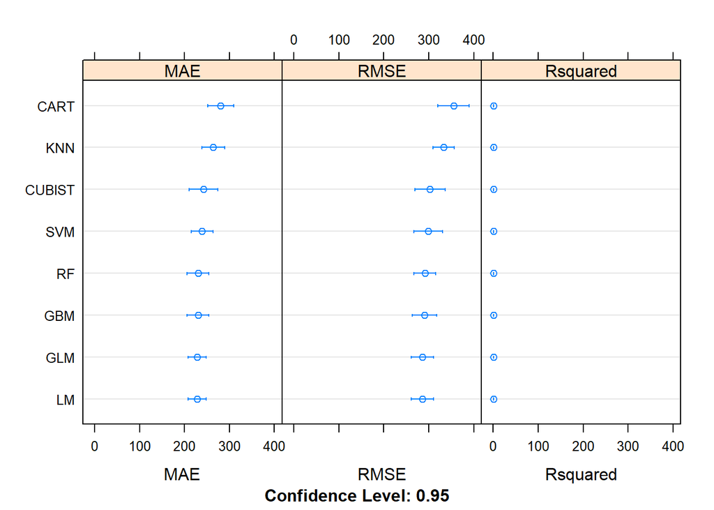

```r
dotplot(results_basic)
```

```r
#--->>> 성능개선 노력 : 데이터가 단순해서 성능개선이 어렵네.
# 1. 데이터 센터링링, 노말라이징
preProc <- c("center", "scale", "BoxCox")  # 데이터 표준화
set.seed(6439)
fit.lm <- train(body_mass_g ~., data = tr_set, method = "lm", metric = metric,
                trControl = trainControl, preProc = preProc)
set.seed(6439)
fit.glmnet <- train(body_mass_g ~., data = tr_set, method = "glmnet",
                    metric = metric, trControl = trainControl, preProc = preProc)
fit.glmnet$bestTune  # 참고로...
```

```
  alpha   lambda
2   0.1 13.77812
```

```r
set.seed(6439)
fit.cart <- train(body_mass_g ~., data = tr_set, method = "rpart",
                  metric = metric, trControl = trainControl, preProc = preProc)
set.seed(6439)
fit.svm <- train(body_mass_g ~., data = tr_set, method = "svmRadial",
                 metric = metric, trControl = trainControl, preProc = preProc)
set.seed(6439)
fit.knn <- train(body_mass_g ~., data = tr_set, method = "knn",
                 metric = metric, trControl = trainControl, preProc = preProc)

set.seed(6439)
fit.rf <- train(body_mass_g ~., data = tr_set, method = "rf",
                metric = metric, trControl = trainControl, preProc = preProc)
set.seed(6439)
fit.gbm <- train(body_mass_g ~., data = tr_set, method = "gbm",
                 metric = metric, trControl = trainControl, preProc = preProc,
                 verbose = F)
set.seed(6439)
fit.cubist <- train(body_mass_g ~., data = tr_set, method = "cubist",
                    metric = metric, trControl = trainControl,preProc = preProc,
                    verbose = F)
# tarnsformed data 결과 종합
results_std <- resamples(list(LM = fit.lm, GLM = fit.glmnet, CART = fit.cart,
                                SVM = fit.svm, KNN = fit.knn,
                                RF = fit.rf, GBM = fit.gbm,CUBIST = fit.cubist))
summary(results_std)
```

```
Call:
summary.resamples(object = results_std)

Models: LM, GLM, CART, SVM, KNN, RF, GBM, CUBIST
Number of resamples: 10

MAE
           Min.  1st Qu.   Median     Mean  3rd Qu.     Max. NA's
LM     202.2503 207.3972 222.7396 229.7346 238.8260 281.6686    0
GLM    198.5366 206.6687 224.0102 230.7365 243.6801 285.2840    0
CART   205.8199 274.0229 283.2599 280.4799 312.4168 324.7025    0
SVM    191.2836 219.8047 233.0318 241.3888 262.9508 311.6746    0
KNN    193.8272 209.4650 225.8929 234.5245 249.6468 318.0556    0
RF     183.5316 207.7278 221.8054 230.1388 255.1200 295.6062    0
GBM    196.0056 205.7077 230.6695 233.6203 256.6744 285.2026    0
CUBIST 198.6048 218.9805 229.3375 240.4532 243.1363 322.1645    0

RMSE
           Min.  1st Qu.   Median     Mean  3rd Qu.     Max. NA's
LM     239.0812 264.6021 283.5577 288.0471 303.1691 344.6149    0
GLM    237.0219 261.6863 284.8916 288.0015 301.9623 350.1284    0
CART   270.0999 329.2187 363.5051 354.9834 393.8831 417.3455    0
SVM    239.1567 272.5976 292.5681 303.2058 325.2046 389.7543    0
KNN    238.5172 269.7352 295.7265 295.7815 316.9588 378.3434    0
RF     233.5700 268.1205 297.9671 291.2277 313.1533 345.2651    0
GBM    238.9198 261.0234 297.2903 291.2783 321.2749 341.8124    0
CUBIST 234.5267 279.0391 291.0650 299.3000 315.2080 384.4392    0

Rsquared
            Min.   1st Qu.    Median      Mean   3rd Qu.      Max. NA's
LM     0.7934032 0.8685634 0.8914414 0.8758885 0.9004031 0.9301778    0
GLM    0.7871380 0.8737878 0.8923628 0.8759911 0.9009053 0.9306553    0
CART   0.7317643 0.7694838 0.7882770 0.8031092 0.8380927 0.8850475    0
SVM    0.7732024 0.8296463 0.8789805 0.8618934 0.8945013 0.9000973    0
KNN    0.7513096 0.8606925 0.8881550 0.8668075 0.8928646 0.9079543    0
RF     0.7933470 0.8642507 0.8857000 0.8729654 0.8970599 0.9097310    0
GBM    0.7974413 0.8728732 0.8793631 0.8738736 0.8916854 0.9183421    0
CUBIST 0.7797753 0.8634100 0.8895068 0.8698184 0.8935404 0.9116381    0
```